# Emmanuel_Omololu_Project_Full_Code_Notebook_EasyVisa (1)

[figure not shown]

Artificial Intelligence and Machine Learning

Ensemble Techniques and Model Tuning

[figure not shown]

Visa Approval Facilitation

# **Problem Statement**

## Context

Business communities in the United States are facing high demand for human resources, but one of the constant challenges is identifying and attracting the right talent, which is perhaps the most important element in remaining competitive. Companies in the United States look for hard-working, talented, and qualified individuals both locally as well as abroad.

The Immigration and Nationality Act (INA) of the US permits foreign workers to come to the United States to work on either a temporary or permanent basis. The act also protects US workers against adverse impacts on their wages or working conditions by ensuring US employers' compliance with statutory requirements when they hire foreign workers to fill workforce shortages. The immigration programs are administered by the Office of Foreign Labor Certification (OFLC).

OFLC processes job certification applications for employers seeking to bring foreign workers into the United States and grants certifications in those cases where employers can demonstrate that there are not sufficient US workers available to perform the work at wages that meet or exceed the wage paid for the occupation in the area of intended employment.

## Objective

In FY 2016, the OFLC processed 775,979 employer applications for 1,699,957 positions for temporary and permanent labor certifications. This was a nine percent increase in the overall number of processed applications from the previous year. The process of reviewing every case is becoming a tedious task as the number of applicants is increasing every year.

The increasing number of applicants every year calls for a Machine Learning based solution that can help in shortlisting the candidates having higher chances of VISA approval. OFLC has hired the firm EasyVisa for data-driven solutions. You as a data scientist at EasyVisa have to analyze the data provided and, with the help of a classification model:

- Facilitate the process of visa approvals.
- Recommend a suitable profile for the applicants for whom the visa should be certified or denied based on the drivers that significantly influence the case status.

## Data Description

The data contains the different attributes of employee and the employer. The detailed data dictionary is given below.

- case_id: ID of each visa application
- continent: Information of continent the employee
- education_of_employee: Information of education of the employee
- has_job_experience: Does the employee has any job experience? Y= Yes; N = No
- requires_job_training: Does the employee require any job training? Y = Yes; N = No
- no_of_employees: Number of employees in the employer's company
- yr_of_estab: Year in which the employer's company was established
- region_of_employment: Information of foreign worker's intended region of employment in the US.
- prevailing_wage: Average wage paid to similarly employed workers in a specific occupation in the area of intended employment. The purpose of the prevailing wage is to ensure that the foreign worker is not underpaid compared to other workers offering the same or similar service in the same area of employment.
- unit_of_wage: Unit of prevailing wage. Values include Hourly, Weekly, Monthly, and Yearly.
- full_time_position: Is the position of work full-time? Y = Full Time Position; N = Part Time Position
- case_status: Flag indicating if the Visa was certified or denied

## Note: This is a sample solution for the project. Projects will NOT be graded on the basis of how well the submission matches this sample solution. Projects will be graded on the basis of the rubric only.

# **Importing necessary libraries**

```python
# Installing the libraries with the specified version.
!pip install numpy==2.0.2 pandas==2.2.2 scikit-learn==1.6.1 matplotlib==3.10.0 seaborn==0.13.2 xgboost==3.0.5 -q --user
```

**Note**: *After running the above cell, kindly restart the notebook kernel and run all cells sequentially from the start again.*

```python
import warnings

warnings.filterwarnings("ignore")

#import librarires for data access nd manipulation
import numpy as np
import pandas as pd

#import libraries for data visualization
import matplotlib.pyplot as plt
import seaborn as sns

#import libraries to split data
from sklearn.model_selection import train_test_split

# To oversample and undersample data
from imblearn.over_sampling import SMOTE
from imblearn. under_sampling import RandomUnderSampler
from sklearn.model_selection import train_test_split, StratifiedKFold, cross_val_score

# Removes the limit for the number of displayed columns
pd.set_option("display.max_columns", None)
# Sets the limit for the number of displayed rows
pd.set_option("display.max_rows", 100)

# Libraries different ensemble classifiers
from sklearn.ensemble import (
  BaggingClassifier,
  RandomForestClassifier,
  AdaBoostClassifier,
  GradientBoostingClassifier
)

# To tune different models
from sklearn.model_selection import RandomizedSearchCV

from xgboost import XGBClassifier
from sklearn.tree import DecisionTreeClassifier

# Libraries to get different metric scores
from sklearn import metrics
from sklearn.metrics import (
  confusion_matrix,
  accuracy_score,
  precision_score,
  recall_score,
  f1_score
)
```

# **Loading the dataset**

```python
from google.colab import drive
drive.mount('/content/drive')
```

```python
# loading data into a pandas dataframe
easy_visa = pd.read_csv("/content/drive/MyDrive/AIML/EasyVisa.csv")
```

```python
# creating a copy of the data
data = easy_visa.copy()
```

# **Overview of the Dataset**

### Viewing the first and last 5 rows of the dataset

```python
data.head(5)
```

|  | case_id | continent | education_of_employee | has_job_experience | requires_job_training | no_of_employees | yr_of_estab | region_of_employment | prevailing_wage | unit_of_wage | full_time_position | case_status |
| --- | --- | --- | --- | --- | --- | --- | --- | --- | --- | --- | --- | --- |
| 0 | EZYV01 | Asia | High School | N | N | 14513 | 2007 | West | 592.2029 | Hour | Y | Denied |
| 1 | EZYV02 | Asia | Master's | Y | N | 2412 | 2002 | Northeast | 83425.6500 | Year | Y | Certified |
| 2 | EZYV03 | Asia | Bachelor's | N | Y | 44444 | 2008 | West | 122996.8600 | Year | Y | Denied |
| 3 | EZYV04 | Asia | Bachelor's | N | N | 98 | 1897 | West | 83434.0300 | Year | Y | Denied |
| 4 | EZYV05 | Africa | Master's | Y | N | 1082 | 2005 | South | 149907.3900 | Year | Y | Certified |

```python
data.tail(5)
```

|  | case_id | continent | education_of_employee | has_job_experience | requires_job_training | no_of_employees | yr_of_estab | region_of_employment | prevailing_wage | unit_of_wage | full_time_position | case_status |
| --- | --- | --- | --- | --- | --- | --- | --- | --- | --- | --- | --- | --- |
| 25475 | EZYV25476 | Asia | Bachelor's | Y | Y | 2601 | 2008 | South | 77092.57 | Year | Y | Certified |
| 25476 | EZYV25477 | Asia | High School | Y | N | 3274 | 2006 | Northeast | 279174.79 | Year | Y | Certified |
| 25477 | EZYV25478 | Asia | Master's | Y | N | 1121 | 1910 | South | 146298.85 | Year | N | Certified |
| 25478 | EZYV25479 | Asia | Master's | Y | Y | 1918 | 1887 | West | 86154.77 | Year | Y | Certified |
| 25479 | EZYV25480 | Asia | Bachelor's | Y | N | 3195 | 1960 | Midwest | 70876.91 | Year | Y | Certified |

- Observations
- Sanity checks

### Checking the shape of the dataset.

```python
data.shape
```

```
(25480, 12)
```

- The dataset has 25480 rows and 12 columns.

### Checking the attribute types

```python
data.info()
```

```
<class 'pandas.core.frame.DataFrame'>
RangeIndex: 25480 entries, 0 to 25479
Data columns (total 12 columns):
 #   Column                 Non-Null Count  Dtype
---  ------                 --------------  -----
 0   case_id                25480 non-null  object
 1   continent              25480 non-null  object
 2   education_of_employee  25480 non-null  object
 3   has_job_experience     25480 non-null  object
 4   requires_job_training  25480 non-null  object
 5   no_of_employees        25480 non-null  int64
 6   yr_of_estab            25480 non-null  int64
 7   region_of_employment   25480 non-null  object
 8   prevailing_wage        25480 non-null  float64
 9   unit_of_wage           25480 non-null  object
 10  full_time_position     25480 non-null  object
 11  case_status            25480 non-null  object
dtypes: float64(1), int64(2), object(9)
memory usage: 2.3+ MB
```

- There are 3 numerical and 9 categorical variables in the data.
- Although stored as object type, variables such as has_job_experience, requires_job_training, and full_time_position are categorical (binary) variables that represent Yes/No type information rather than true text features.

### Checking the statistical summary

```python
data.describe(include="all")
```

|  | case_id | continent | education_of_employee | has_job_experience | requires_job_training | no_of_employees | yr_of_estab | region_of_employment | prevailing_wage | unit_of_wage | full_time_position | case_status |
| --- | --- | --- | --- | --- | --- | --- | --- | --- | --- | --- | --- | --- |
| count | 25480 | 25480 | 25480 | 25480 | 25480 | 25480.000000 | 25480.000000 | 25480 | 25480.000000 | 25480 | 25480 | 25480 |
| unique | 25480 | 6 | 4 | 2 | 2 | NaN | NaN | 5 | NaN | 4 | 2 | 2 |
| top | EZYV25480 | Asia | Bachelor's | Y | N | NaN | NaN | Northeast | NaN | Year | Y | Certified |
| freq | 1 | 16861 | 10234 | 14802 | 22525 | NaN | NaN | 7195 | NaN | 22962 | 22773 | 17018 |
| mean | NaN | NaN | NaN | NaN | NaN | 5667.043210 | 1979.409929 | NaN | 74455.814592 | NaN | NaN | NaN |
| std | NaN | NaN | NaN | NaN | NaN | 22877.928848 | 42.366929 | NaN | 52815.942327 | NaN | NaN | NaN |
| min | NaN | NaN | NaN | NaN | NaN | -26.000000 | 1800.000000 | NaN | 2.136700 | NaN | NaN | NaN |
| 25% | NaN | NaN | NaN | NaN | NaN | 1022.000000 | 1976.000000 | NaN | 34015.480000 | NaN | NaN | NaN |
| 50% | NaN | NaN | NaN | NaN | NaN | 2109.000000 | 1997.000000 | NaN | 70308.210000 | NaN | NaN | NaN |
| 75% | NaN | NaN | NaN | NaN | NaN | 3504.000000 | 2005.000000 | NaN | 107735.512500 | NaN | NaN | NaN |
| max | NaN | NaN | NaN | NaN | NaN | 602069.000000 | 2016.000000 | NaN | 319210.270000 | NaN | NaN | NaN |

- Dataset Size: 25,480 observations with 12 features
- Missing Values: No missing values present
- Variable Types: 3 numerical and 9 categorical variables
- Categorical Trends: Asia, Bachelor’s degree, full-time jobs, and Certified cases dominate
- Numerical Distribution: Numerical variables show high variability and skewness
- Data Quality: Presence of outliers and an invalid negative value in number of employees

### Checking for missing values

```python
# checking for null values
data.isnull().sum()
```

|  | 0 |
| --- | --- |
| case_id | 0 |
| continent | 0 |
| education_of_employee | 0 |
| has_job_experience | 0 |
| requires_job_training | 0 |
| no_of_employees | 0 |
| yr_of_estab | 0 |
| region_of_employment | 0 |
| prevailing_wage | 0 |
| unit_of_wage | 0 |
| full_time_position | 0 |
| case_status | 0 |

**dtype:** int64

- There are no missing values in the dataset.

### Checking for duplicate values

```python
# checking for duplicate values
data.duplicated().sum()
```

```
np.int64(0)
```

- There are no duplicate values in the data.

# **Exploratory Data Analysis (EDA)**

- EDA is an important part of any project involving data.
- It is important to investigate and understand the data better before building a model with it.
- A few questions have been mentioned below which will help you approach the analysis in the right manner and generate insights from the data.
- A thorough analysis of the data, in addition to the questions mentioned below, should be done.

**Leading Questions**

What is the distribution of visa case statuses (certified vs. denied)?

1. What is the distribution of visa case statuses (certified vs. denied)?
2. How does the education level of employees impact visa approval rates?
3. Is there a significant difference in visa approval rates between employees with and without prior job experience?
4. How does the prevailing wage affect visa approval? Do higher wages lead to higher chances of approval?
5. Do certain regions in the US have higher visa approval rates compared to others?
6. How does the number of employees in a company influence visa approval? Do larger companies have a higher approval rate?
7. Are visa approval rates different across various continents of employees? Which continent has the highest and lowest approval rates?

**Statistical Summary of data**

```python
### Statistical summary of the data
data.describe().T
```

|  | count | mean | std | min | 25% | 50% | 75% | max |
| --- | --- | --- | --- | --- | --- | --- | --- | --- |
| no_of_employees | 25480.0 | 5667.043210 | 22877.928848 | -26.0000 | 1022.00 | 2109.00 | 3504.0000 | 602069.00 |
| yr_of_estab | 25480.0 | 1979.409929 | 42.366929 | 1800.0000 | 1976.00 | 1997.00 | 2005.0000 | 2016.00 |
| prevailing_wage | 25480.0 | 74455.814592 | 52815.942327 | 2.1367 | 34015.48 | 70308.21 | 107735.5125 | 319210.27 |

**Observations**

- The number of employees variable is highly right-skewed with extreme outliers and includes an invalid negative value, indicating potential data quality issues.
- The year of establishment shows that most companies were founded around the late 1900s with relatively low variation and a few very old firms.
- The prevailing wage exhibits wide dispersion and right skewness, reflecting significant variation in salary levels across cases.

**Fixing negative values in employees data**

```python
data.loc[data['no_of_employees'] < 0].shape
```

```
(33, 12)
```

33 data entry errors will be treated as absolute values

```python
data['no_of_employees'] =  abs(data['no_of_employees'])
```

**Checking categorical variables data uniqueness**

```python
categorical_columns = data.select_dtypes(include=['object']).columns

for column in categorical_columns:
    unique_values_count = data[column].value_counts()
    print(f"Unique values in column '{column}':")
    print(unique_values_count)
    print()
```

```
Unique values in column 'case_id':
case_id
EZYV25480    1
EZYV01       1
EZYV02       1
EZYV03       1
EZYV04       1
            ..
EZYV13       1
EZYV12       1
EZYV11       1
EZYV10       1
EZYV09       1
Name: count, Length: 25480, dtype: int64

Unique values in column 'continent':
continent
Asia             16861
Europe            3732
North America     3292
South America      852
Africa             551
Oceania            192
Name: count, dtype: int64

Unique values in column 'education_of_employee':
education_of_employee
Bachelor's     10234
Master's        9634
High School     3420
Doctorate       2192
Name: count, dtype: int64

Unique values in column 'has_job_experience':
has_job_experience
Y    14802
N    10678
Name: count, dtype: int64

Unique values in column 'requires_job_training':
```

[output cut: 18 more lines]

```
Week       272
Month       89
Name: count, dtype: int64

Unique values in column 'full_time_position':
full_time_position
Y    22773
N     2707
Name: count, dtype: int64

Unique values in column 'case_status':
case_status
Certified    17018
Denied        8462
Name: count, dtype: int64
```

**Observations**

- Each **case_id** is unique, confirming that every record represents a distinct application.
- Most applications originate from **Asia**, followed by Europe and North America.
- The majority of employees hold a **Bachelor’s or Master’s degree**, with fewer having High School or Doctorate qualifications.
- More applicants **have prior job experience** than those without experience.
- Most positions **do not require job training**, indicating a preference for skilled workers.
- Employment is mainly concentrated in the **Northeast, South, and West** regions.
- Wages are predominantly reported on a **yearly basis**, with other units used infrequently.
- The vast majority of roles are **full-time positions**.
- **Certified cases** significantly outnumber **denied cases**, indicating a higher approval rate.

```python
# checking the number of unique values
data["case_id"].nunique()
```

```
25480
```

Since all the values in this column are unique. It's okay to drop the column

```python
data.drop("case_id", axis=1, inplace=True)
```

### Univariate Analysis

```python
def histogram_boxplot(data, feature, figsize=(15, 10), kde=False, bins=None):
  """
  Boxplot and histogram combined

  data: dataframe
  feature: dataframe column
  figsize: size of figure (default (15,10))
  kde: whether to show the density curve (default False)
  bins: number of bins for histogram (default None)
  """

  f2, (ax_box2, ax_hist2) = plt.subplots(
    nrows=2, # Number of rows of the subplot grid= 2
    sharex=True, # x-axis will be shared among all subplots
    gridspec_kw={"height_ratios": (0.25, 0.75)},
    figsize=figsize
  )
  # creating the 2 subplots
  sns.boxplot(
    data=data, x=feature, ax=ax_box2, showmeans=True, color="violet"
  ) # boxplot will be created and a triangle will indicate the mean value of the column
  sns.histplot(
    data=data, x=feature, kde=kde, ax=ax_hist2, bins=bins
  ) if bins else sns.histplot(
      data=data, x=feature, kde=kde, ax=ax_hist2
  ) # For histogram
  ax_hist2.axvline(
  data[feature].mean(), color="green", linestyle=" -- "
  ) # Add mean to the histogram
  ax_hist2.axvline(
  data[feature].median(), color="black", linestyle="-"
  ) # Add median to the histogram
```

```python
# function to create labeled barplots

def labeled_barplot(data, feature, perc=False, n=None):
  """
  Barplot with pepcentage at the top

  data: dataframe
  feature: dataframe column
  perc: whether to display percentages instead of count (default is False)
  n: displays the top n category levels (default is None, i.e., display all Levels)
  """
  total = len(data[feature]) # length of the column
  count = data[feature].nunique()
  if n is None:
    plt.figure(figsize=(count + 1, 5))
  else:
    plt.figure(figsize=(n + 1, 5))

  plt.xticks(rotation=90, fontsize=15)
  plt.xticks(rotation=90, fontsize=15)
  ax = sns.countplot (
    data=data,
    x=feature,
    palette="Paired",
    order=data[feature].value_counts().index[:n].sort_values(),
  )

  for p in ax.patches:
    if perc == True:
      label = "{:.1f}%".format(
        100 * p.get_height()/total
      ) # percentage of each class of the category
    else:
      label = p.get_height() # count of each level of the category

    x = p.get_x() + p.get_width() / 2 # width of the plot
    y = p.get_height() # height of the plot

    ax.annotate(
      label,
      (x, y),
      ha="center",
      va="center",
      size=12,
      xytext=(0, 5),
      textcoords="offset points"
    ) # annotate the percentage

  plt.show() # show the plot
```

**Observations on education of employee**

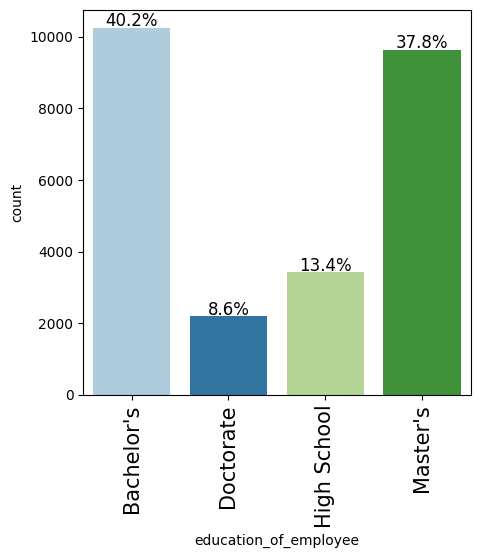

```python
labeled_barplot(data, "education_of_employee", perc=True)
```

The bar chart shows the distribution of employees' education levels in the dataset:

- The largest group holds a **Bachelor’s degree** (40.2%).
- The second largest group has a **Master’s degree** (37.8%).
- Employees with a **High School** education make up 13.4%.
- Those with a **Doctorate** degree represent the smallest group at 8.6%.

This confirms that most employees are highly educated, with the majority holding Bachelor’s or Master’s degrees.

**Observations on region of employment**

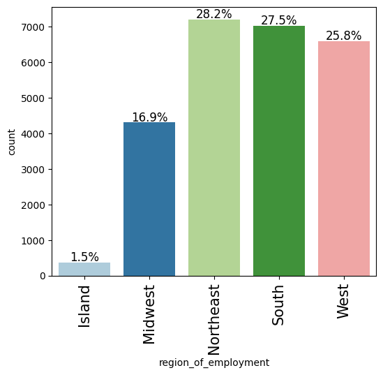

```python
labeled_barplot(data, "region_of_employment", perc=True)
```

The bar chart illustrates the distribution of employment cases by region:

- The **Northeast** region has the highest share at **28.2%**.
- The **South** closely follows with **27.5%**.
- The **West** region accounts for **25.8%** of cases.
- The **Midwest** makes up **16.9%**.
- The **Island** region has the smallest portion, only **1.5%**.

This shows that most employment cases are concentrated in the Northeast, South, and West regions, with minimal representation from the Island region.

**Observations on job experience**

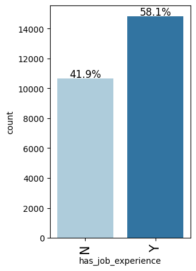

```python
labeled_barplot(data, "has_job_experience", perc=True)
```

The bar chart shows the distribution of applicants based on job experience:

- **58.1%** of applicants **have prior job experience** (marked as "Y").
- **41.9%** of applicants **do not have job experience** (marked as "N").

This indicates that the majority of applicants come with some level of prior job experience.

**Observations on case status**

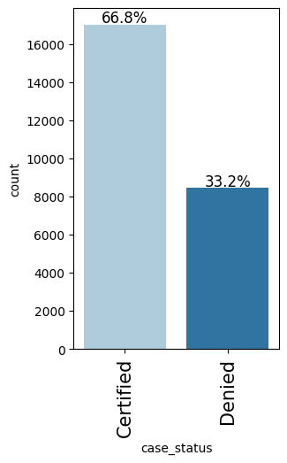

```python
labeled_barplot(data, "case_status", perc=True)
```

- Majority of cases are **Certified (66.8%)**, indicating approvals are more common than denials.
- **Denied cases account for 33.2%**, representing a significant portion of total cases.
- Certification rate is **approximately twice** the denial rate.
- Overall outcomes suggest a **generally favorable approval trend**.
- The noticeable share of denials highlights the need for **further analysis of rejection factors**.

### Bivariate Analysis

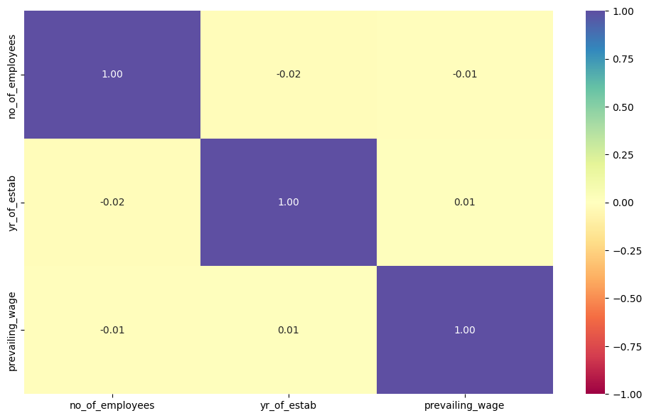

```python
# defining the size of the plot
plt.figure(figsize=(12, 7))
num_features = data.select_dtypes(include=['int64', 'float64']).columns.tolist()

# plotting the heatmap for correlation
sns.heatmap(
    data[num_features].corr(),annot=True, vmin=-1, vmax=1, fmt=".2f", cmap="Spectral"
);
```

- **Very weak correlations** among all variables, with coefficients close to zero.
- **Number of employees** has a negligible negative correlation with **year of establishment** (-0.02).
- **Number of employees** and **prevailing wage** are almost uncorrelated (-0.01).
- **Year of establishment** shows a very slight positive correlation with **prevailing wage** (0.01).
- Overall, the variables appear **largely independent**, indicating no strong linear relationships.

```python
def stacked_barplot(data, predictor, target):
  """
  data: input dataset
  predictor: independent variable
  target: target variable
  """
  count = data[predictor].nunique()
  sorter = data[target].value_counts().index[-1]

  # creating a crosstab for predictor vs target
  tab1 = pd.crosstab(
      data[predictor],
      data[target],
      margins=True,
  ).sort_values(by=sorter, ascending=False)

  print(tab1)
  print("-" * 120)


  tab = pd.crosstab(
      data[predictor],
      data[target],
      normalize='index'    # normalizing by dividing each row by its row total
  ).sort_values(by=sorter, ascending=False)    # sorting the resulting crosstab


  # Plot the stacked bar chart
  tab.plot(kind='bar', stacked=True, figsize=(7, 5))    # creating a stacked bar chart from the normalized crosstab
  plt.xlabel(predictor)
  plt.legend(loc='upper left', bbox_to_anchor=(1, 1), title=target);    # adding a legend for the 'Approval' column
```

```python
### function to plot distributions wrt target

def distribution_plot_wrt_target(data, predictor, target):

  fig, axs = plt.subplots(2, 2, figsize=(12, 10))

  target_uniq = data[target].unique()

  axs[0, 0].set_title("Distribution of target for target=" + str(target_uniq[0]))
  sns.histplot(
    data=data[data[target] == target_uniq[0]],
    x=predictor,
    kde=True,
    ax=axs[0, 0],
    color="teal",
    stat="density",
  )

  axs [0, 1].set_title("Distribution of target for target=" + str(target_uniq[1]))
  sns.histplot(
    data=data[data[target] == target_uniq[1]],
    x=predictor,
    kde=True,
    ax=axs[0, 1],
    color="orange",
    stat="density",
  )

  axs[1, 0].set_title("Boxplot w.r.t target")
  sns.boxplot(data=data, x=target, y=predictor, ax=axs[1, 0], palette="gist_rainbow")


  axs [1, 1].set_title("Boxplot (without outliers) w.r.t target")
  sns.boxplot(
    data=data,
    x=target,
    y=predictor,
    ax=axs[1, 1],
    showfliers=False,
    palette="gist_rainbow"
  )

  plt.tight_layout()
  plt.show()
```

```
case_status            Certified  Denied    All
education_of_employee
All                        17018    8462  25480
Bachelor's                  6367    3867  10234
High School                 1164    2256   3420
Master's                    7575    2059   9634
Doctorate                   1912     280   2192
------------------------------------------------------------------------------------------------------------------------
```

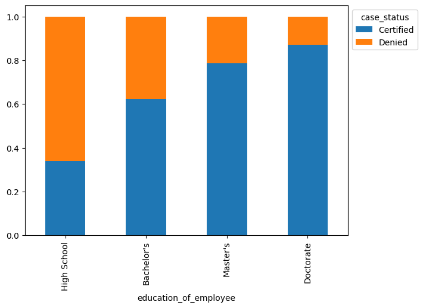

```python
stacked_barplot(data, "education_of_employee", "case_status")
```

- **Certification rates increase with higher education levels**.
- **Doctorate holders** show the highest certification proportion and the lowest denial rate.
- **Master’s degree holders** also have a strong likelihood of certification, though slightly lower than doctorates.
- **Bachelor’s degree holders** have a more balanced split, with a noticeable share of denials.
- **High school level** cases have the **highest denial rate**, exceeding certifications.
- Overall, the chart suggests a **positive relationship between education level and approval likelihood**.

```
case_status    Certified  Denied    All
continent
All                17018    8462  25480
Asia               11012    5849  16861
North America       2037    1255   3292
Europe              2957     775   3732
South America        493     359    852
Africa               397     154    551
Oceania              122      70    192
------------------------------------------------------------------------------------------------------------------------
```

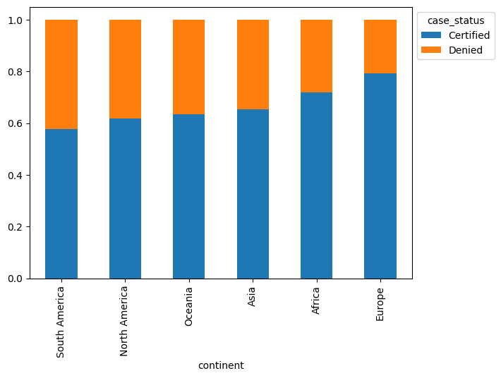

```python
stacked_barplot1 = stacked_barplot(data, "continent", "case_status")
```

Here are some clear takeaways from the chart:

- **Europe has the highest certification rate** (~80%) and the **lowest denial rate**, standing out from the rest.
- **Africa follows Europe**, with a relatively high certification share (~72%) compared to other regions.
- **Asia and Oceania sit in the middle**, with certification rates around the mid-60% range.
- **North America** is slightly lower than Asia/Oceania, with a noticeable denial portion.
- **South America has the lowest certification rate** (~58%) and the **highest denial rate** among all continents.
- Overall trend: **Certification rates generally increase from South America → Europe**, while denial rates decrease accordingly.

```
case_status         Certified  Denied    All
has_job_experience
All                     17018    8462  25480
N                        5994    4684  10678
Y                       11024    3778  14802
------------------------------------------------------------------------------------------------------------------------
```

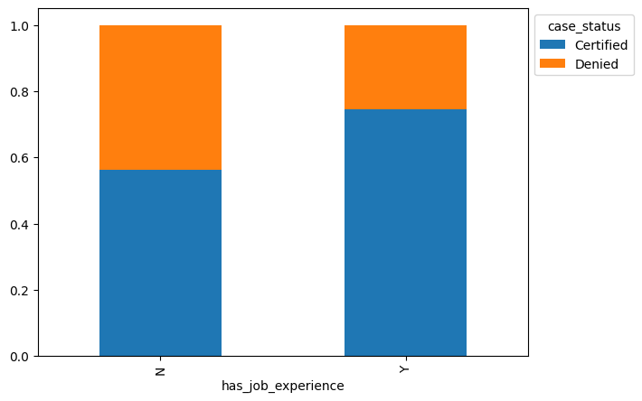

```python
stacked_barplot(data, "has_job_experience", "case_status")
```

Here are the key observations from this chart:

- **Applicants with job experience (“Y”) have a much higher certification rate** (~74%) compared to those without experience.
- **Applicants without job experience (“N”) face a higher denial rate**, with denials making up nearly **44%** of cases.
- Job experience appears to be a **strong positive factor** in certification outcomes.
- The gap between certified and denied cases is **significantly wider** for experienced applicants than for inexperienced ones.

In short: **having job experience greatly improves the likelihood of certification**.

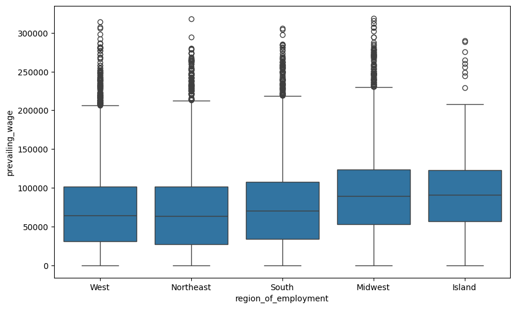

```python
# Prevailing wages based on region of employment
plt.figure(figsize=(10, 6))
sns.boxplot(data=data, x='region_of_employment', y='prevailing_wage');
```

Here are the main observations from the boxplot:

Overall, wage levels vary notably by region, with **Midwest and Island offering higher typical wages**, while **West and Northeast trend lower**.

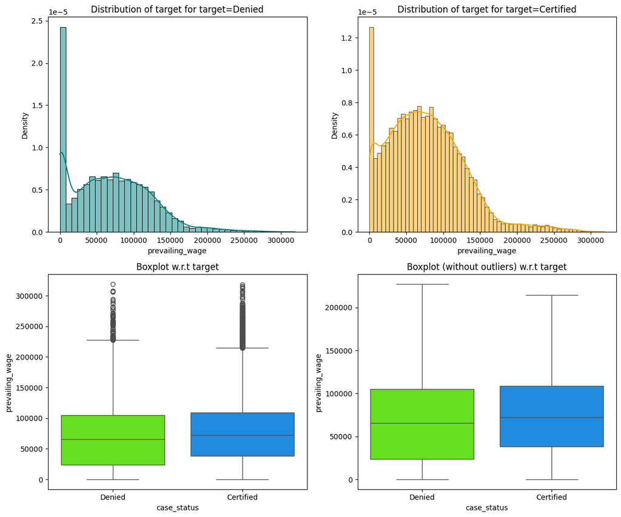

```python
distribution_plot_wrt_target(data, "prevailing_wage", "case_status")
```

```
case_status   Certified  Denied    All
unit_of_wage
All               17018    8462  25480
Year              16047    6915  22962
Hour                747    1410   2157
Week                169     103    272
Month                55      34     89
------------------------------------------------------------------------------------------------------------------------
```

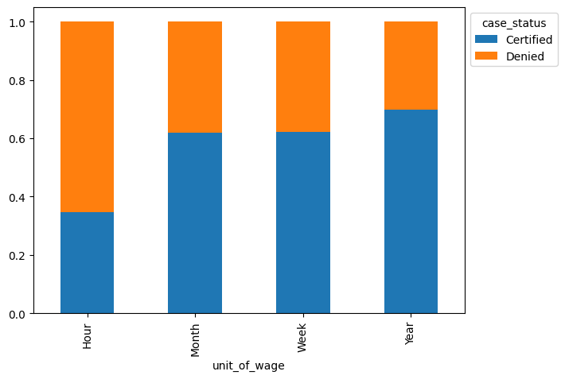

```python
stacked_barplot(data, "unit_of_wage", "case_status")
```

# **Data Pre-processing**

- Missing value treatment (if needed)
- Feature engineering (if needed)
- Outlier detection and treatment (if needed)
- Preparing data for modeling
- Any other preprocessing steps (if needed)

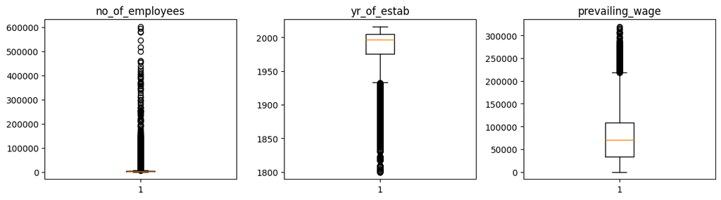

```python
#outlier detection

numeric_columns = data.select_dtypes(include=['int64', 'float64']).columns.tolist()

plt.figure(figsize=(15, 12))

for i, column in enumerate(numeric_columns, 1):
    plt.subplot(4,4, i + 1)
    plt.boxplot(data[column])
    plt.title(column)

plt.tight_layout()
plt.show()
```

- **Number of employees** is extremely **right-skewed** with many small firms and a few very large employers
- Presence of **numerous extreme outliers** in employee count (up to hundreds of thousands)
- Median employer size is **relatively small**, despite very large maximum values
- **Year of establishment** is concentrated around **recent decades**
- Median establishment year is close to **2000**, indicating many relatively young firms
- Older firms (1800s–early 1900s) appear as **lower-end outliers**
- **Prevailing wage** shows strong **right skewness**
- Most wages are clustered in the **lower-to-mid range**, with a long high-wage tail
- Several **high-wage outliers** (> $200k) are present
- Overall, all three variables show **non-normal distributions**, suggesting the need for **log transformation, robust scaling, or outlier handling** before modeling

#### **Data preparation for modelling**

- Our objective is to predict whether a visa application will be **certified**
- Before building the model, we will **encode categorical features**
- We will then **split the dataset into training and testing sets** to evaluate the model’s performance on unseen data

```python
data["case_status"] = data["case_status"].apply(lambda x: 1 if x == "Certified" else 0)
X = data.drop(["case_status"], axis=1)
y = data["case_status"]

X = pd.get_dummies(X, drop_first=True)
# Splitting data into training and validation set:
X_train, X_val, y_train, y_val = train_test_split(
  X, y, test_size=0.30, random_state=1, stratify=y
)

#Test data
X_val,X_test,y_val,y_test = train_test_split(
  X_val, y_val, test_size=0.1,random_state=1,stratify=y_val
)
```

```python
print("Shape of Training set : ", X_train.shape)
print("Shape of Validation set : ", X_val.shape)
print("Shape of test set : ", X_test.shape)
print("_" * 50)

print("Percentage of classes in training set:")
print(y_train.value_counts(normalize=True))
print("_" * 50)

print("Percentage of classes in validation set:")
print(y_val.value_counts(normalize=True))
print("_" * 50)

print("Percentage of classes in test set:")
print(y_test.value_counts(normalize=True))
```

```
Shape of Training set :  (17836, 21)
Shape of Validation set :  (6879, 21)
Shape of test set :  (765, 21)
__________________________________________________
Percentage of classes in training set:
case_status
1    0.667919
0    0.332081
Name: proportion, dtype: float64
__________________________________________________
Percentage of classes in validation set:
case_status
1    0.66783
0    0.33217
Name: proportion, dtype: float64
__________________________________________________
Percentage of classes in test set:
case_status
1    0.667974
0    0.332026
Name: proportion, dtype: float64
```

# **Model Building**

**Model Evaluation Criterion**

A model can make incorrect predictions in two ways:

1. Predicting that a visa application will be **certified** when it should actually be **denied**.
2. Predicting that a visa application will be **denied** when it should actually be **certified**.

**Which case is more important?**

Both types of errors are equally important:

- If a visa is certified when it should have been denied, an unsuitable foreign worker may fill the position, potentially reducing job opportunities for U.S. citizens.
- If a visa is denied when it should have been certified, the U.S. may lose a qualified professional who could contribute positively to the economy.

**How do we reduce these losses?**

**Implementation approach**

We define a utility function to collate all the metrics into a single data frame, and another to plot the confusion matrix.

```python
# defining a function to compute different metrics to check performance of a classification model built using sklearn
def model_performance_classification(model, predictors, target):
    """
    Function to compute different metrics to check classification model performance

    model: classifier
    predictors: independent variables
    target: dependent variable
    """

    # predicting using the independent variables
    pred = model.predict(predictors)

    acc = accuracy_score(target, pred)  # to compute Accuracy
    recall = recall_score(target, pred)  # to compute Recall
    precision = precision_score(target, pred)  # to compute Precision
    f1 = f1_score(target, pred)  # to compute F1-score

    # creating a dataframe of metrics
    df_perf = pd.DataFrame(
        {"Accuracy": acc, "Recall": recall, "Precision": precision, "F1": f1,},
        index=[0],
    )

    return df_perf
```

```python
def plot_confusion_matrix(model, predictors, target):
    """
    To plot the confusion_matrix with percentages

    model: classifier
    predictors: independent variables
    target: dependent variable
    """
    # Predict the target values using the provided model and predictors
    y_pred = model.predict(predictors)

    # Compute the confusion matrix comparing the true target values with the predicted values
    cm = confusion_matrix(target, y_pred)

    # Create labels for each cell in the confusion matrix with both count and percentage
    labels = np.asarray(
        [
            ["{0:0.0f}".format(item) + "\n{0:.2%}".format(item / cm.flatten().sum())]
            for item in cm.flatten()
        ]
    ).reshape(2, 2)    # reshaping to a matrix

    # Set the figure size for the plot
    plt.figure(figsize=(6, 4))

    # Plot the confusion matrix as a heatmap with the labels
    sns.heatmap(cm, annot=labels, fmt="")

    # Add a label to the y-axis
    plt.ylabel("True label")

    # Add a label to the x-axis
    plt.xlabel("Predicted label")
```

```python
#defining scorer
scorer = metrics.make_scorer(metrics.f1_score)
```

**Model building with original data**

```python
models = [] # Empty list to store all the models

# Appending models into the list
models.append(("Bagging", BaggingClassifier(random_state=1)))
models.append(("Random forest", RandomForestClassifier(random_state=1)))
models.append(("GB", GradientBoostingClassifier(random_state=1)))
models.append(("Adaboost", AdaBoostClassifier(random_state=1)))
models.append(("Xgboost", XGBClassifier(random_state=1, eval_metric="logloss")))
models.append(("dtree", DecisionTreeClassifier(random_state=1)))

results = [] # Empty list to store all model's CV scores
names = [] # Empty list to store name of the models

# loop through all models to get the mean cross validated score
print("\n" "Cross-Validation performance on training dataset:" "\n")

for name, model in models:
  kfold = StratifiedKFold(
    n_splits=5, shuffle=True, random_state=1
  ) # Setting number of splits equal to 5
  cv_result = cross_val_score(
    estimator=model, X=X_train, y=y_train, scoring = scorer, cv=kfold
  )

  results.append(cv_result)
  names.append(name)
  print("{}: {}".format(name, cv_result.mean()))

print("\n" "Validation Performance:" "\n")

for name, model in models:
  model.fit(X_train, y_train)
  scores = f1_score(y_val, model.predict(X_val))
  print("{}: {}".format(name, scores))
```

```
Cross-Validation performance on training dataset:

Bagging: 0.7756586246579394
Random forest: 0.8037837241749051
GB: 0.823039791269532
Adaboost: 0.8203377989495703
Xgboost: 0.8095211182586954
dtree: 0.7410652876513099

Validation Performance:

Bagging: 0.7675817565350541
Random forest: 0.7972364702187794
GB: 0.8195818459969403
Adaboost: 0.8158053488839735
Xgboost: 0.8083918974782968
dtree: 0.7477497255762898
```

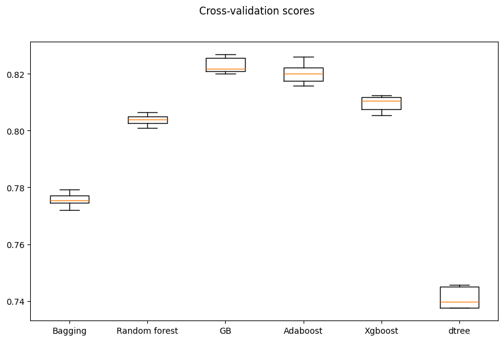

```python
# Plotting boxplots for CV scores of all models defined above

fig = plt.figure(figsize=(10, 6))
fig.suptitle("Cross-validation scores")
ax = fig.add_subplot(111)

plt.boxplot(results)
ax.set_xticklabels(names)

plt.show()
```

#### **Model Building with oversampled data**

```python
print("Before OverSampling, counts of label '1': {}".format(sum(y_train == 1)))
print("Before OverSampling, counts of label '0': {} \n".format(sum(y_train == 0)))

# Synthetic Minority Over Sampling Technique
sm = SMOTE(sampling_strategy=1, k_neighbors=5, random_state=1)
X_train_over, y_train_over = sm.fit_resample(X_train, y_train)

print("After OverSampling, counts of label '1': {}".format(sum(y_train_over == 1)))
print("After OverSampling, counts of label '0': {} \n".format(sum(y_train_over == 0)))

print("After OverSampling, the shape of train_X: {}".format(X_train_over.shape))
print("After OverSampling, the shape of train_y: {} \n".format(y_train_over.shape))
```

```
Before OverSampling, counts of label '1': 11913
Before OverSampling, counts of label '0': 5923

After OverSampling, counts of label '1': 11913
After OverSampling, counts of label '0': 11913

After OverSampling, the shape of train_X: (23826, 21)
After OverSampling, the shape of train_y: (23826,)
```

```python
models = [] # Empty list to store all the models

# Appending models into the list
models.append(("Bagging", BaggingClassifier(random_state=1)))
models.append(("Random forest", RandomForestClassifier(random_state=1)))
models.append(("GB", GradientBoostingClassifier(random_state=1)))
models.append(("Adaboost", AdaBoostClassifier(random_state=1)))
models.append(("Xgboost", XGBClassifier(random_state=1, eval_metric="logloss")))
models.append(("dtree", DecisionTreeClassifier(random_state=1)))

results = [] # Empty list to store all model's CV scores
names = [] # Empty list to store name of the models

# loop through all models to get the mean cross validated score
print("\n" "Cross-Validation performance on training dataset:" "\n")

for name, model in models:
  kfold = StratifiedKFold(
    n_splits=5, shuffle=True, random_state=1
  ) # Setting number of splits equal to 5
  cv_result = cross_val_score(
    estimator=model, X=X_train_over, y=y_train_over, scoring = scorer, cv=kfold
  )

  results.append(cv_result)
  names.append(name)
  print("{}: {}".format(name, cv_result.mean()))

print("\n" "Validation Performance:" "\n")

for name, model in models:
  model.fit(X_train_over, y_train_over)
  scores = f1_score(y_val, model.predict(X_val))
  print("{}: {}".format(name, scores))
```

```
Cross-Validation performance on training dataset:

Bagging: 0.7553714301070087
Random forest: 0.7935193362866556
GB: 0.8076949280007495
Adaboost: 0.8013161599972107
Xgboost: 0.799430071068073
dtree: 0.7236479557474234

Validation Performance:

Bagging: 0.7606724176067242
Random forest: 0.7953896584540552
GB: 0.8125259228535877
Adaboost: 0.8120255086547221
Xgboost: 0.8039950062421972
dtree: 0.7387687188019967
```

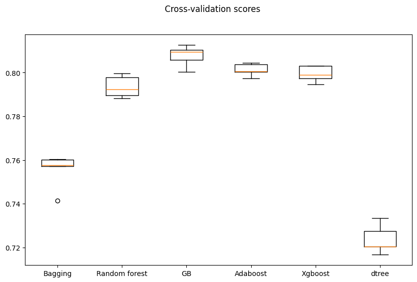

```python
# Plotting boxplots for CV scores of all models defined above

fig = plt.figure(figsize=(10, 6))
fig.suptitle("Cross-validation scores")
ax = fig.add_subplot(111)

plt.boxplot(results)
ax.set_xticklabels(names)

plt.show()
```

- **Gradient Boosting (GB)** achieves the **highest median score**, indicating the best overall performance.
- **AdaBoost** performs very close to GB, with a **slightly lower median** but **consistent results**.
- **XGBoost** shows **strong performance**, ranking just below the other boosting methods.
- **Random Forest** has **moderate accuracy**, better than Bagging but weaker than boosting models.
- **Bagging** performs lower than Random Forest, with a **noticeably smaller median score**.
- **Decision Tree (dtree)** has the **lowest performance** and the **largest variability**, suggesting instability.
- Overall, **boosting-based models outperform bagging and single-tree models**.
- **Lower spread in boosting models** indicates **better generalization across folds**.

#### **Model Building with undersampled data**

```python
random_sample_data = RandomUnderSampler(random_state=1, sampling_strategy=1)
X_train_under, y_train_under = random_sample_data.fit_resample(X_train, y_train)

print("Before UnderSampling, counts of label '1': {}".format(sum(y_train == 1)))
print("Before UnderSampling, counts of label '0': {} \n".format(sum(y_train == 0)))

print("After UnderSampling, counts of label '1': {}".format(sum(y_train_un == 1)))
print("After UnderSampling, counts of label '0': {} \n".format(sum(y_train_un == 0)))

print("After UnderSampling, the shape of train_X: {}".format(X_train_un.shape))
print("After UnderSampling, the shape of train_y: {} \n".format(y_train_un.shape))
```

[output not shown]

```python
models = [] # Empty list to store all the models

# Appending models into the list
models.append(("Bagging", BaggingClassifier(random_state=1)))
models.append(("Random forest", RandomForestClassifier(random_state=1)))
models.append(("GB", GradientBoostingClassifier(random_state=1)))
models.append(("Adaboost", AdaBoostClassifier(random_state=1)))
models.append(("Xgboost", XGBClassifier(random_state=1, eval_metric="logloss")))
models.append(("dtree", DecisionTreeClassifier(random_state=1)))

results = [] # Empty list to store all model's CV scores
names = [] # Empty list to store name of the models

# loop through all models to get the mean cross validated score
print("\n" "Cross-Validation performance on training dataset:" "\n")

for name, model in models:
  kfold = StratifiedKFold(
    n_splits=5, shuffle=True, random_state=1
  ) # Setting number of splits equal to 5
  cv_result = cross_val_score(
    estimator=model, X=X_train_under, y=y_train_under, scoring = scorer, cv=kfold
  )

  results.append(cv_result)
  names.append(name)
  print("{}: {}".format(name, cv_result.mean()))

print("\n" "Validation Performance:" "\n")

for name, model in models:
  model.fit(X_train_under, y_train_under)
  scores = f1_score(y_val, model.predict(X_val))
  print("{}: {}".format(name, scores))
```

```
Cross-Validation performance on training dataset:

Bagging: 0.6411413525524321
Random forest: 0.6875011408129813
GB: 0.7131358906535971
Adaboost: 0.6949405744215158
Xgboost: 0.6944693136408734
dtree: 0.617022679979161

Validation Performance:

Bagging: 0.6916956737941323
Random forest: 0.734144015259895
GB: 0.7608695652173914
Adaboost: 0.7604202747950584
Xgboost: 0.7423652871123688
dtree: 0.6839080459770115
```

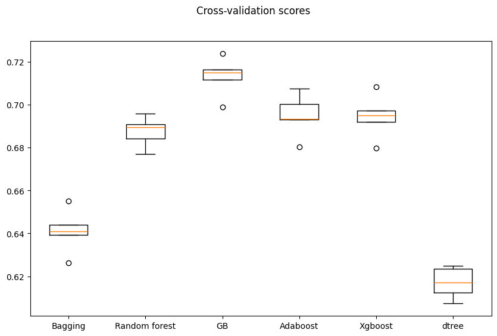

```python
# Plotting boxplots for CV scores of all models defined above

fig = plt.figure(figsize=(10, 6))
fig.suptitle("Cross-validation scores")
ax = fig.add_subplot(111)

plt.boxplot(results)
ax.set_xticklabels(names)

plt.show()
```

- **Gradient Boosting (GB)** has the **highest median score** (~0.71–0.72), making it the best-performing model here.
- **XGBoost** and **AdaBoost** show **similar median performance** (~0.69–0.70), slightly below GB.
- **Random Forest** performs moderately well (~0.68–0.69) but trails the boosting methods.
- **Bagging** has a **lower median score** (~0.64) with a relatively tight spread.
- **Decision Tree (dtree)** again shows the **lowest performance** (~0.61–0.62).
- **Outliers** are present in most models, especially in GB, AdaBoost, and XGBoost, indicating some fold sensitivity.
- **Boosting methods consistently outperform bagging and single-tree models**.
- Overall performance levels are **lower than the previous plot**, suggesting a harder dataset or different evaluation setting.

#### **Cross-Comparison Summary**

While original data yields the highest accuracy, **oversampling provides a better trade-off between performance and class balance**, whereas undersampling sacrifices accuracy for fairness.

# **Model Performance Improvement**

#### Hyperparameter Tuning

```python
# Creating new pipeline with best parameters
tuned_ada = AdaBoostClassifier(
  n_estimators= 200, learning_rate= 0.2, estimator= DecisionTreeClassifier(max_depth=3, random_state=1)
)

tuned_ada.fit(X_train_over, y_train_over)
```

```
AdaBoostClassifier(estimator=DecisionTreeClassifier(max_depth=3,
                                                    random_state=1),
                   learning_rate=0.2, n_estimators=200)
```

```python
ada_train_perf = model_performance_classification(tuned_ada, X_train_over, y_train_over)
ada_train_perf
```

|  | Accuracy | Recall | Precision | F1 |
| --- | --- | --- | --- | --- |
| 0 | 0.793839 | 0.839419 | 0.76929 | 0.802826 |

```python
ada_val_perf = model_performance_classification(tuned_ada, X_val, y_val)
ada_val_perf
```

|  | Accuracy | Recall | Precision | F1 |
| --- | --- | --- | --- | --- |
| 0 | 0.734118 | 0.835002 | 0.78174 | 0.807494 |

#### Tuning Random forest using undersample data

```python
# Creating new pipeline with best parameters
tuned_random_forest = RandomForestClassifier(
  max_features="sqrt",
  random_state=1,
  max_samples=0.5,
  n_estimators=300,
  min_samples_leaf=2,
)

tuned_random_forest.fit(X_train_under, y_train_under)
```

```
RandomForestClassifier(max_samples=0.5, min_samples_leaf=2, n_estimators=300,
                       random_state=1)
```

```python
random_forest_train_perf = model_performance_classification(tuned_random_forest, X_train_under, y_train_under)
random_forest_train_perf
```

|  | Accuracy | Recall | Precision | F1 |
| --- | --- | --- | --- | --- |
| 0 | 0.842141 | 0.842985 | 0.841564 | 0.842274 |

```python
random_forest_val_perf = model_performance_classification(tuned_random_forest, X_val, y_val)
random_forest_val_perf
```

|  | Accuracy | Recall | Precision | F1 |
| --- | --- | --- | --- | --- |
| 0 | 0.69952 | 0.709621 | 0.816429 | 0.759287 |

#### Tuning with Gradient boosting - Oversampled Data

```python
# Creating new pipeline with best parameters
tuned_gbm = GradientBoostingClassifier(
  max_features=0.5,
  random_state=1,
  learning_rate=1,
  n_estimators=125,
  subsample=0.7
)

tuned_gbm.fit(X_train_over, y_train_over)
```

```
GradientBoostingClassifier(learning_rate=1, max_features=0.5, n_estimators=125,
                           random_state=1, subsample=0.7)
```

```python
gbm_train_perf = model_performance_classification(tuned_gbm, X_train_over, y_train_over)
gbm_train_perf
```

|  | Accuracy | Recall | Precision | F1 |
| --- | --- | --- | --- | --- |
| 0 | 0.816209 | 0.859481 | 0.791023 | 0.823832 |

```python
gbm_val_perf = model_performance_classification(tuned_gbm, X_val, y_val)
gbm_val_perf
```

|  | Accuracy | Recall | Precision | F1 |
| --- | --- | --- | --- | --- |
| 0 | 0.711586 | 0.818894 | 0.765568 | 0.791334 |

#### Tuning with XGBoost

```python
xgb = XGBClassifier(
  random_state=1,
  eval_metric="logloss",
  subsample=0.8,
  scale_pos_weight=10,
  n_estimators=250,
  learning_rate=0.2,
  gamma=0,
)

xgb.fit(X_train_over, y_train_over)
```

```
XGBClassifier(base_score=None, booster=None, callbacks=None,
              colsample_bylevel=None, colsample_bynode=None,
              colsample_bytree=None, device=None, early_stopping_rounds=None,
              enable_categorical=False, eval_metric='logloss',
              feature_types=None, feature_weights=None, gamma=0,
              grow_policy=None, importance_type=None,
              interaction_constraints=None, learning_rate=0.2, max_bin=None,
              max_cat_threshold=None, max_cat_to_onehot=None,
              max_delta_step=None, max_depth=None, max_leaves=None,
              min_child_weight=None, missing=nan, monotone_constraints=None,
              multi_strategy=None, n_estimators=250, n_jobs=None,
              num_parallel_tree=None, ...)
```

```python
xgb_train_perf = model_performance_classification(xgb, X_train_over, y_train_over)
xgb_train_perf
```

|  | Accuracy | Recall | Precision | F1 |
| --- | --- | --- | --- | --- |
| 0 | 0.808654 | 1.0 | 0.723227 | 0.839387 |

```python
xgb_val_perf = model_performance_classification(xgb, X_val, y_val)
xgb_val_perf
```

|  | Accuracy | Recall | Precision | F1 |
| --- | --- | --- | --- | --- |
| 0 | 0.69734 | 0.968872 | 0.696557 | 0.810452 |

Overfitting firther increased.

## **Note**

1. Sample parameter grids have been provided to do necessary hyperparameter tuning. These sample grids are expected to provide a balance between model performance improvement and execution time. One can extend/reduce the parameter grid based on execution time and system configuration.
- Please note that if the parameter grid is extended to improve the model performance further, the execution time will increase
2. The models chosen in this notebook are based on test runs. One can update the best models as obtained upon code execution and tune them for best performance.
- For Gradient Boosting:

```
param_grid = {
    "init": [AdaBoostClassifier(random_state=1),DecisionTreeClassifier(random_state=1)],
    "n_estimators": np.arange(50,110,25),
    "learning_rate": [0.01,0.1,0.05],
    "subsample":[0.7,0.9],
    "max_features":[0.5,0.7,1],
}
```

- For Adaboost:

```
param_grid = {
    "n_estimators": np.arange(50,110,25),
    "learning_rate": [0.01,0.1,0.05],
    "base_estimator": [
        DecisionTreeClassifier(max_depth=2, random_state=1),
        DecisionTreeClassifier(max_depth=3, random_state=1),
    ],
}
```

- For Bagging Classifier:

```
param_grid = {
    'max_samples': [0.8,0.9,1],
    'max_features': [0.7,0.8,0.9],
    'n_estimators' : [30,50,70],
}
```

- For Random Forest:

```
param_grid = {
    "n_estimators": [50,110,25],
    "min_samples_leaf": np.arange(1, 4),
    "max_features": [np.arange(0.3, 0.6, 0.1),'sqrt'],
    "max_samples": np.arange(0.4, 0.7, 0.1)
}
```

- For Decision Trees:

```
param_grid = {
    'max_depth': np.arange(2,6),
    'min_samples_leaf': [1, 4, 7],
    'max_leaf_nodes' : [10, 15],
    'min_impurity_decrease': [0.0001,0.001]
}
```

- For XGBoost:

```
param_grid={'n_estimators':np.arange(50,110,25),
            'scale_pos_weight':[1,2,5],
            'learning_rate':[0.01,0.1,0.05],
            'gamma':[1,3],
            'subsample':[0.7,0.9]
}
```

# **Model Comparison and Final Model Selection**

```python
# training performance comparison

models_train_comp_df = pd.concat(
  [
  gbm_train_perf.T,
  xgb_train_perf.T,
  ada_train_perf.T,
  random_forest_train_perf.T,
  ],
  axis=1,
)

models_train_comp_df.columns = [
"Gradient Boosting tuned with oversampled data",
"XGBoost tuned with oversampled data",
"AdaBoost tuned with oversampled data",
"Random forest tuned with undersampled data",
]

print("Training performance comparison:")

models_train_comp_df
```

```
Training performance comparison:
```

|  | Gradient Boosting tuned with oversampled data | XGBoost tuned with oversampled data | AdaBoost tuned with oversampled data | Random forest tuned with undersampled data |
| --- | --- | --- | --- | --- |
| Accuracy | 0.816209 | 0.808654 | 0.793839 | 0.842141 |
| Recall | 0.859481 | 1.000000 | 0.839419 | 0.842985 |
| Precision | 0.791023 | 0.723227 | 0.769290 | 0.841564 |
| F1 | 0.823832 | 0.839387 | 0.802826 | 0.842274 |

```python
# validation performance comparison

models_val_comp_df = pd.concat(
  [
  gbm_val_perf.T,
  xgb_val_perf.T,
  ada_val_perf.T,
  random_forest_val_perf.T,
  ],
  axis=1,
)

models_val_comp_df.columns = [
"Gradient Boosting tuned with oversampled data",
"XGBoost tuned with oversampled data",
"AdaBoost tuned with oversampled data",
"Random forest tuned with undersampled data",
]

print("Validation performance comparison:")

models_val_comp_df
```

```
Validation performance comparison:
```

|  | Gradient Boosting tuned with oversampled data | XGBoost tuned with oversampled data | AdaBoost tuned with oversampled data | Random forest tuned with undersampled data |
| --- | --- | --- | --- | --- |
| Accuracy | 0.711586 | 0.697340 | 0.734118 | 0.699520 |
| Recall | 0.818894 | 0.968872 | 0.835002 | 0.709621 |
| Precision | 0.765568 | 0.696557 | 0.781740 | 0.816429 |
| F1 | 0.791334 | 0.810452 | 0.807494 | 0.759287 |

**Now we have our final model, let's see how it performs on test data**

```python
ada_test = model_performance_classification(tuned_ada, X_test, y_test)
ada_test
```

|  | Accuracy | Recall | Precision | F1 |
| --- | --- | --- | --- | --- |
| 0 | 0.752941 | 0.849315 | 0.794872 | 0.821192 |

##### Feature Importance

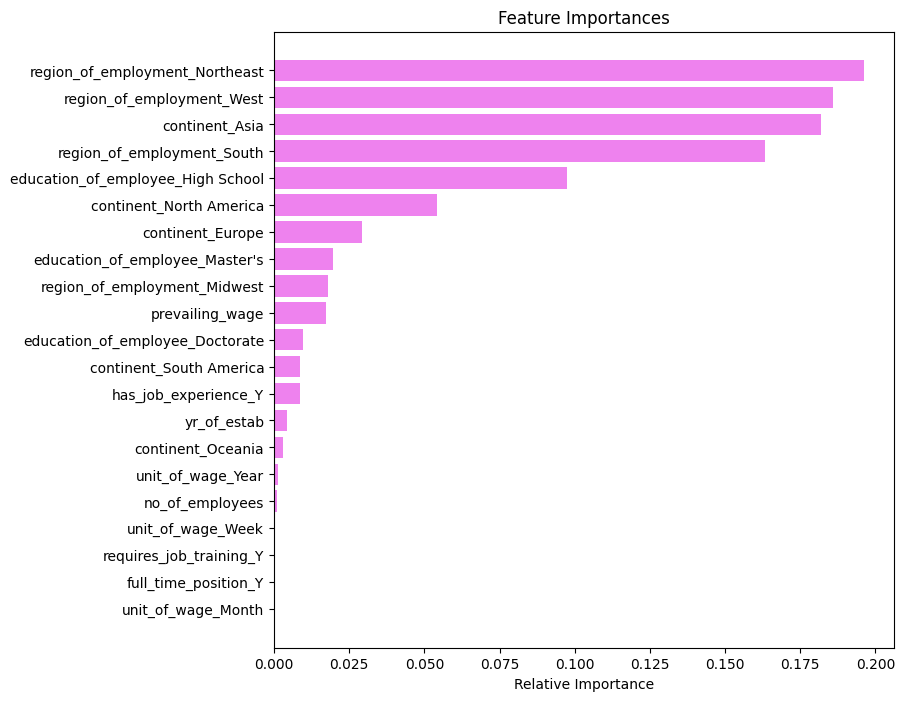

```python
# importance of features in the tree building
feature_names = X_train.columns
importances = tuned_ada.feature_importances_
indices = np.argsort(importances)

plt.figure(figsize=(8, 8))
plt.title("Feature Importances")
plt.barh(range(len(indices)), importances[indices], color="violet", align="center")
plt.yticks(range(len(indices)), [feature_names[i] for i in indices])
plt.xlabel("Relative Importance")
plt.show()
```

# **Actionable Insights and Recommendations**

### **Recommendations**

- **Use job experience as a primary filter** in applicant pre-screening.
- **Encourage employers to offer competitive wages** aligned with regional market standards.
- **Prioritize applications from established organizations** with proven approval history.
- **Incorporate regional weighting** in the ML model to reflect approval patterns.
- **Deploy the ML classifier as a decision-support tool** to rank applicants by approval probability.
- **Continuously retrain the model** with new data to adapt to policy or labor market changes.
- **Provide feedback to applicants** on key improvement areas (experience, wage level, employer type).
- **Use model outputs for workload reduction**, allowing officers to focus on borderline cases.